# Data Visualization: Ford Go Bike 2019

# Data exploring and cleaning.

```python
df.columns
```

```
Index(['duration_sec', 'start_time', 'end_time', 'start_station_id',
       'start_station_name', 'start_station_latitude',
       'start_station_longitude', 'end_station_id', 'end_station_name',
       'end_station_latitude', 'end_station_longitude', 'bike_id', 'user_type',
       'member_birth_year', 'member_gender', 'bike_share_for_all_trip'],
      dtype='object')
```

```python
df.shape
```

```
(2845161, 16)
```

```python
df.info(verbose=True,null_counts=True)
```

```
<class 'pandas.core.frame.DataFrame'>
RangeIndex: 2845161 entries, 0 to 2845160
Data columns (total 16 columns):
 #   Column                   Non-Null Count    Dtype
---  ------                   --------------    -----
 0   duration_sec             2845161 non-null  int64
 1   start_time               2845161 non-null  object
 2   end_time                 2845161 non-null  object
 3   start_station_id         2751340 non-null  float64
 4   start_station_name       2751941 non-null  object
 5   start_station_latitude   2845161 non-null  float64
 6   start_station_longitude  2845161 non-null  float64
 7   end_station_id           2749172 non-null  float64
 8   end_station_name         2749724 non-null  object
 9   end_station_latitude     2845161 non-null  float64
 10  end_station_longitude    2845161 non-null  float64
 11  bike_id                  2845161 non-null  int64
 12  user_type                2845161 non-null  object
 13  member_birth_year        1753003 non-null  float64
 14  member_gender            1753354 non-null  object
 15  bike_share_for_all_trip  2601902 non-null  object
dtypes: float64(7), int64(2), object(7)
memory usage: 347.3+ MB
```

```python
pd.set_option('float_format', '{:f}'.format)
df.describe()
```

|  | duration_sec | start_station_id | start_station_latitude | start_station_longitude | end_station_id | end_station_latitude | end_station_longitude | bike_id | member_birth_year |
| --- | --- | --- | --- | --- | --- | --- | --- | --- | --- |
| count | 2845161.000000 | 2751340.000000 | 2845161.000000 | 2845161.000000 | 2749172.000000 | 2845161.000000 | 2845161.000000 | 2845161.000000 | 1753003.000000 |
| mean | 851.228645 | 127.334806 | 37.764011 | -122.347332 | 124.911484 | 37.763616 | -122.345024 | 23235.861587 | 1983.087962 |
| std | 2318.543801 | 108.768156 | 0.132964 | 0.303194 | 108.201563 | 0.194180 | 0.549749 | 108175.598473 | 10.442886 |
| min | 60.000000 | 3.000000 | 0.000000 | -122.514299 | 3.000000 | 0.000000 | -122.514287 | 4.000000 | 1881.000000 |
| 25% | 356.000000 | 37.000000 | 37.770407 | -122.411726 | 30.000000 | 37.770407 | -122.410662 | 1328.000000 | 1978.000000 |
| 50% | 565.000000 | 92.000000 | 37.780955 | -122.397405 | 90.000000 | 37.781074 | -122.397086 | 2550.000000 | 1985.000000 |
| 75% | 885.000000 | 196.000000 | 37.795393 | -122.288665 | 195.000000 | 37.795812 | -122.290231 | 3639.000000 | 1991.000000 |
| max | 912110.000000 | 498.000000 | 45.510000 | 0.000000 | 498.000000 | 45.510000 | 0.000000 | 999941.000000 | 2000.000000 |

# Percentage of null for each columns.

```python
for index,name in enumerate(df.columns):
    null_count=df[name].isnull().sum();
    Percentage=(null_count/df.shape[0])*100
    print("Percentage of null: {0:.2f}% for column:{1}".format(Percentage,name))
```

```
Percentage of null: 0.00% for column:duration_sec
Percentage of null: 0.00% for column:start_time
Percentage of null: 0.00% for column:end_time
Percentage of null: 3.30% for column:start_station_id
Percentage of null: 3.28% for column:start_station_name
Percentage of null: 0.00% for column:start_station_latitude
Percentage of null: 0.00% for column:start_station_longitude
Percentage of null: 3.37% for column:end_station_id
Percentage of null: 3.35% for column:end_station_name
Percentage of null: 0.00% for column:end_station_latitude
Percentage of null: 0.00% for column:end_station_longitude
Percentage of null: 0.00% for column:bike_id
Percentage of null: 0.00% for column:user_type
Percentage of null: 38.39% for column:member_birth_year
Percentage of null: 38.37% for column:member_gender
Percentage of null: 8.55% for column:bike_share_for_all_trip
```

```python
df.isnull().sum()
```

```
duration_sec                     0
start_time                       0
end_time                         0
start_station_id             93821
start_station_name           93220
start_station_latitude           0
start_station_longitude          0
end_station_id               95989
end_station_name             95437
end_station_latitude             0
end_station_longitude            0
bike_id                          0
user_type                        0
member_birth_year          1092158
member_gender              1091807
bike_share_for_all_trip     243259
dtype: int64
```

## Define: drop null.

```python
# code.
df.dropna(inplace=True)
#test
df.isnull().sum()
```

```
duration_sec               0
start_time                 0
end_time                   0
start_station_id           0
start_station_name         0
start_station_latitude     0
start_station_longitude    0
end_station_id             0
end_station_name           0
end_station_latitude       0
end_station_longitude      0
bike_id                    0
user_type                  0
member_birth_year          0
member_gender              0
bike_share_for_all_trip    0
dtype: int64
```

```python
print(df.shape)
print(2506983-2262979)
```

```
(1741556, 16)
244004
```

## Define:

change start and ending time to datetime object.

```python
#code
df["start_time"]=pd.to_datetime(df["start_time"])
df["end_time"]=pd.to_datetime(df["end_time"])
```

```python
#test
df.info(verbose=True,null_counts=True)
```

```
<class 'pandas.core.frame.DataFrame'>
Int64Index: 1741556 entries, 0 to 2845160
Data columns (total 16 columns):
 #   Column                   Non-Null Count    Dtype
---  ------                   --------------    -----
 0   duration_sec             1741556 non-null  int64
 1   start_time               1741556 non-null  datetime64[ns]
 2   end_time                 1741556 non-null  datetime64[ns]
 3   start_station_id         1741556 non-null  float64
 4   start_station_name       1741556 non-null  object
 5   start_station_latitude   1741556 non-null  float64
 6   start_station_longitude  1741556 non-null  float64
 7   end_station_id           1741556 non-null  float64
 8   end_station_name         1741556 non-null  object
 9   end_station_latitude     1741556 non-null  float64
 10  end_station_longitude    1741556 non-null  float64
 11  bike_id                  1741556 non-null  int64
 12  user_type                1741556 non-null  object
 13  member_birth_year        1741556 non-null  float64
 14  member_gender            1741556 non-null  object
 15  bike_share_for_all_trip  1741556 non-null  object
dtypes: datetime64[ns](2), float64(7), int64(2), object(5)
memory usage: 225.9+ MB
```

```python
df.bike_share_for_all_trip.value_counts()
```

```
No     1580067
Yes     161489
Name: bike_share_for_all_trip, dtype: int64
```

## Define:

change values yes,no to boolean true and false.

```python
#code
df.replace(to_replace="No",value=False,inplace=True)
df.replace(to_replace="Yes",value=True,inplace=True)

#test
df.bike_share_for_all_trip.value_counts()
```

```
False    1580067
True      161489
Name: bike_share_for_all_trip, dtype: int64
```

```python
df.duration_sec.value_counts()[:10]
```

```
371    2440
357    2434
330    2434
342    2429
370    2426
327    2423
337    2419
345    2414
351    2412
322    2409
Name: duration_sec, dtype: int64
```

```python
df.duration_sec[:10]
```

```
0      598
1      943
2    18587
3    18558
4      885
5      921
6      277
7      285
8      363
9      226
Name: duration_sec, dtype: int64
```

## Define:

```python
# setting duration to minutes and change columns name
#code
df.duration_sec=df.duration_sec/60
df.rename(columns={"duration_sec":"duration_min"},inplace=True)
#test
```

```python
df.duplicated().sum()
```

```
0
```

```python
df.user_type.value_counts()
```

```
Subscriber    1542367
Customer       199189
Name: user_type, dtype: int64
```

```python
df.user_type.value_counts()
```

```
Subscriber    1542367
Customer       199189
Name: user_type, dtype: int64
```

```python
df.start_station_name.value_counts()[:10]
```

```
San Francisco Caltrain Station 2  (Townsend St at 4th St)    36119
San Francisco Caltrain (Townsend St at 4th St)               33641
Market St at 10th St                                         33275
San Francisco Ferry Building (Harry Bridges Plaza)           33226
Berry St at 4th St                                           32416
Montgomery St BART Station (Market St at 2nd St)             30212
Powell St BART Station (Market St at 4th St)                 28784
The Embarcadero at Sansome St                                28379
Steuart St at Market St                                      26806
Howard St at Beale St                                        25734
Name: start_station_name, dtype: int64
```

```python
df.end_station_name.value_counts()[:10]
```

```
San Francisco Caltrain Station 2  (Townsend St at 4th St)    47926
San Francisco Caltrain (Townsend St at 4th St)               41171
San Francisco Ferry Building (Harry Bridges Plaza)           39076
Montgomery St BART Station (Market St at 2nd St)             34148
Market St at 10th St                                         32912
The Embarcadero at Sansome St                                31944
Berry St at 4th St                                           31530
Powell St BART Station (Market St at 4th St)                 30330
Steuart St at Market St                                      26991
Powell St BART Station (Market St at 5th St)                 23811
Name: end_station_name, dtype: int64
```

```python
def haversine(lat1, lon1, lat2, lon2, to_radians=True, earth_radius=6371):
    """

    Calculate the great circle distance between two points
    on the earth (specified in decimal degrees or in radians)

    All (lat, lon) coordinates must have numeric dtypes and be of equal length.

    """
    if to_radians:
        lat1, lon1, lat2, lon2 = np.radians([lat1, lon1, lat2, lon2])

    a = np.sin((lat2-lat1)/2.0)**2 + \
        np.cos(lat1) * np.cos(lat2) * np.sin((lon2-lon1)/2.0)**2

    return earth_radius * 2 * np.arcsin(np.sqrt(a))
```

# Haversine formula

> Haversine Formula – Calculate geographic distance on earth. If you have two different latitude – longitude values of two different point on earth, then with the help of Haversine Formula, you can easily compute the great-circle distance (The shortest distance between two points on the surface of a Sphere). The term Haversine was coined by Prof. James Inman in 1835. Haversine is very popular and frequently used formula when developing a GIS (Geographic Information System) application or analyzing path and fields.

### sources.

[wikipedia page Haversine](https://en.wikipedia.org/wiki/Haversine_formula)

stackoverflow Question-1

stackoverflow Question-2

I want to have the distance between the start and end location so the below cordinate is of a location that I know to test the formula

```python
lat1=37.775745
lon1=-122.213037
lat2=37.808894
lon2=-122.25646
haversine(lat1,lon1,lat2,lon2)
```

```
5.305220342028568
```

[figure not shown]

```python
from IPython.display import Image
Image (filename="../img.png")
```

```python
df[["start_station_latitude",
        "start_station_longitude",
        "end_station_latitude",
        "end_station_longitude"]].head(1)
```

|  | start_station_latitude | start_station_longitude | end_station_latitude | end_station_longitude |
| --- | --- | --- | --- | --- |
| 0 | 37.784872 | -122.400876 | 37.764478 | -122.402570 |

## Define:

add distance column and apply the haversine function to cordinantes column.

```python
# code: applying the function to the dataframe
df["distance_km"]=df.apply(lambda x: haversine(x["start_station_latitude"],
                                                        x["start_station_longitude"],
                                                       x["end_station_latitude"],
                                                       x["end_station_longitude"]),axis=1)
```

```python
#test
df.sort_values(by="distance_km",ascending=False).head()
```

|  | duration_min | start_time | end_time | start_station_id | start_station_name | start_station_latitude | start_station_longitude | end_station_id | end_station_name | end_station_latitude | end_station_longitude | bike_id | user_type | member_birth_year | member_gender | bike_share_for_all_trip | distance_km |
| --- | --- | --- | --- | --- | --- | --- | --- | --- | --- | --- | --- | --- | --- | --- | --- | --- | --- |
| 2078944 | 363.933333 | 2018-03-29 14:25:47.670 | 2018-03-29 20:29:44.284 | 16.000000 | Steuart St at Market St | 37.794130 | -122.394430 | 303.000000 | San Pedro St at Hedding St | 37.352601 | -121.905733 | 319 | Customer | 1974.000000 | Female | False | 65.309254 |
| 1181371 | 52.166667 | 2018-05-12 18:05:17.320 | 2018-05-12 18:57:28.062 | 5.000000 | Powell St BART Station (Market St at 5th St) | 37.783899 | -122.408445 | 243.000000 | Bancroft Way at College Ave | 37.869360 | -122.254337 | 4075 | Subscriber | 1995.000000 | Male | False | 16.537983 |
| 1993110 | 46.900000 | 2018-10-12 09:49:30.458 | 2018-10-12 10:36:25.368 | 248.000000 | Telegraph Ave at Ashby Ave | 37.855956 | -122.259795 | 101.000000 | Potrero Ave at 15th St (Temporary Location) | 37.766629 | -122.407706 | 3508 | Customer | 1978.000000 | Male | False | 16.355227 |
| 295905 | 38.700000 | 2018-09-21 19:14:05.434 | 2018-09-21 19:52:47.540 | 58.000000 | Market St at 10th St | 37.776619 | -122.417385 | 241.000000 | Ashby BART Station | 37.852477 | -122.270213 | 1107 | Subscriber | 1999.000000 | Male | False | 15.436509 |
| 87711 | 53.233333 | 2018-02-05 23:25:31.577 | 2018-02-06 00:18:46.446 | 23.000000 | The Embarcadero at Steuart St | 37.791464 | -122.391034 | 243.000000 | Bancroft Way at College Ave | 37.869360 | -122.254337 | 3665 | Subscriber | 1997.000000 | Other | True | 14.803843 |

```python
df.sort_values(by="distance_km",ascending=True).head()
```

|  | duration_min | start_time | end_time | start_station_id | start_station_name | start_station_latitude | start_station_longitude | end_station_id | end_station_name | end_station_latitude | end_station_longitude | bike_id | user_type | member_birth_year | member_gender | bike_share_for_all_trip | distance_km |
| --- | --- | --- | --- | --- | --- | --- | --- | --- | --- | --- | --- | --- | --- | --- | --- | --- | --- |
| 182176 | 39.200000 | 2018-11-10 12:47:59.150 | 2018-11-10 13:27:11.695 | 377.000000 | Fell St at Stanyan St | 37.771917 | -122.453704 | 377.000000 | Fell St at Stanyan St | 37.771917 | -122.453704 | 2978 | Customer | 1984.000000 | Female | False | 0.000000 |
| 476901 | 35.283333 | 2018-06-23 16:30:42.559 | 2018-06-23 17:05:59.702 | 122.000000 | 19th St at Mission St | 37.760299 | -122.418892 | 122.000000 | 19th St at Mission St | 37.760299 | -122.418892 | 3876 | Subscriber | 1961.000000 | Male | False | 0.000000 |
| 2049100 | 1.333333 | 2018-10-03 20:46:14.939 | 2018-10-03 20:47:35.683 | 134.000000 | Valencia St at 24th St | 37.752428 | -122.420628 | 134.000000 | Valencia St at 24th St | 37.752428 | -122.420628 | 770 | Subscriber | 1986.000000 | Male | False | 0.000000 |
| 2126215 | 2.133333 | 2018-03-17 17:23:23.338 | 2018-03-17 17:25:31.507 | 73.000000 | Pierce St at Haight St | 37.771793 | -122.433708 | 73.000000 | Pierce St at Haight St | 37.771793 | -122.433708 | 1329 | Subscriber | 1988.000000 | Male | False | 0.000000 |
| 176010 | 33.216667 | 2018-11-12 11:58:59.864 | 2018-11-12 12:32:13.415 | 152.000000 | 47th St at San Pablo Ave | 37.835632 | -122.281051 | 152.000000 | 47th St at San Pablo Ave | 37.835632 | -122.281051 | 474 | Subscriber | 1973.000000 | Male | False | 0.000000 |

```python
print("99.9%:",np.percentile(df.distance_km,99.9))
print("100%:",np.percentile(df.distance_km,100))
```

```
99.9%: 6.824927532125965
100%: 65.3092539013712
```

```python
print(df[df["distance_km"]>10_000].shape)
df[df["distance_km"]>10_000]
```

```
(0, 17)
```

|  | duration_min | start_time | end_time | start_station_id | start_station_name | start_station_latitude | start_station_longitude | end_station_id | end_station_name | end_station_latitude | end_station_longitude | bike_id | user_type | member_birth_year | member_gender | bike_share_for_all_trip | distance_km |
| --- | --- | --- | --- | --- | --- | --- | --- | --- | --- | --- | --- | --- | --- | --- | --- | --- | --- |

## Note:

```python
print(df[df.distance_km==0].shape)
df[df.distance_km==0].head()
#this is the same starting and ending points
```

```
(41855, 17)
```

|  | duration_min | start_time | end_time | start_station_id | start_station_name | start_station_latitude | start_station_longitude | end_station_id | end_station_name | end_station_latitude | end_station_longitude | bike_id | user_type | member_birth_year | member_gender | bike_share_for_all_trip | distance_km |
| --- | --- | --- | --- | --- | --- | --- | --- | --- | --- | --- | --- | --- | --- | --- | --- | --- | --- |
| 27 | 16.566667 | 2018-02-28 22:17:06.664 | 2018-02-28 22:33:41.122 | 235.000000 | Union St at 10th St | 37.807239 | -122.289370 | 235.000000 | Union St at 10th St | 37.807239 | -122.289370 | 1277 | Subscriber | 1969.000000 | Male | False | 0.000000 |
| 45 | 15.166667 | 2018-02-28 21:54:18.773 | 2018-02-28 22:09:29.363 | 232.000000 | MLK Jr Way at 14th St | 37.806163 | -122.276040 | 232.000000 | MLK Jr Way at 14th St | 37.806163 | -122.276040 | 1097 | Subscriber | 1983.000000 | Male | False | 0.000000 |
| 69 | 17.350000 | 2018-02-28 21:34:45.200 | 2018-02-28 21:52:06.534 | 296.000000 | 5th St at Virginia St | 37.325998 | -121.877120 | 296.000000 | 5th St at Virginia St | 37.325998 | -121.877120 | 1091 | Subscriber | 1994.000000 | Male | True | 0.000000 |
| 109 | 34.366667 | 2018-02-28 20:51:08.139 | 2018-02-28 21:25:31.067 | 296.000000 | 5th St at Virginia St | 37.325998 | -121.877120 | 296.000000 | 5th St at Virginia St | 37.325998 | -121.877120 | 47 | Subscriber | 1993.000000 | Male | True | 0.000000 |
| 957 | 1.116667 | 2018-02-28 18:01:40.866 | 2018-02-28 18:02:48.556 | 256.000000 | Hearst Ave at Euclid Ave | 37.875112 | -122.260553 | 256.000000 | Hearst Ave at Euclid Ave | 37.875112 | -122.260553 | 3513 | Subscriber | 1995.000000 | Male | False | 0.000000 |

```python
print(df[df.end_station_latitude==0].shape)
df[df.end_station_latitude==0].head()
```

```
(0, 17)
```

|  | duration_min | start_time | end_time | start_station_id | start_station_name | start_station_latitude | start_station_longitude | end_station_id | end_station_name | end_station_latitude | end_station_longitude | bike_id | user_type | member_birth_year | member_gender | bike_share_for_all_trip | distance_km |
| --- | --- | --- | --- | --- | --- | --- | --- | --- | --- | --- | --- | --- | --- | --- | --- | --- | --- |

```python
print(df[df.start_station_latitude==0].shape)
df[df.start_station_latitude==0].head()
```

```
(0, 17)
```

|  | duration_min | start_time | end_time | start_station_id | start_station_name | start_station_latitude | start_station_longitude | end_station_id | end_station_name | end_station_latitude | end_station_longitude | bike_id | user_type | member_birth_year | member_gender | bike_share_for_all_trip | distance_km |
| --- | --- | --- | --- | --- | --- | --- | --- | --- | --- | --- | --- | --- | --- | --- | --- | --- | --- |

## Define:

- droping rows where distance equals zero.

```python
#code
df=df[df.distance_km!=0]
#test
print(df[df.distance_km==0].shape)
print(df.shape)
df[df.distance_km==0].head()
```

```
(0, 17)
(1699701, 17)
```

|  | duration_min | start_time | end_time | start_station_id | start_station_name | start_station_latitude | start_station_longitude | end_station_id | end_station_name | end_station_latitude | end_station_longitude | bike_id | user_type | member_birth_year | member_gender | bike_share_for_all_trip | distance_km |
| --- | --- | --- | --- | --- | --- | --- | --- | --- | --- | --- | --- | --- | --- | --- | --- | --- | --- |

# Define:

Remove outliers.

```python
#code
df=df[df["distance_km"]<10_000]
#test
print(df[df.distance_km<10_000].shape)
print(df.shape)
df[df.distance_km>10_000].head()
```

```
(1699701, 17)
(1699701, 17)
```

|  | duration_min | start_time | end_time | start_station_id | start_station_name | start_station_latitude | start_station_longitude | end_station_id | end_station_name | end_station_latitude | end_station_longitude | bike_id | user_type | member_birth_year | member_gender | bike_share_for_all_trip | distance_km |
| --- | --- | --- | --- | --- | --- | --- | --- | --- | --- | --- | --- | --- | --- | --- | --- | --- | --- |

## Define:

adding date columns based on date.

```python
#code
df["day"]=df.start_time.dt.dayofweek
days=["Monday","Tuesday","Wednesday","Thursday","Friday","Saturday","Sunday"]
for i in range(7):
    df.day.replace(to_replace=i,value=days[i],inplace=True)
#test
df[["start_time","day"]].sample(10)
```

|  | start_time | day |
| --- | --- | --- |
| 1678252 | 2018-08-31 19:03:24.373 | Friday |
| 67899 | 2018-02-09 19:23:40.485 | Friday |
| 200582 | 2018-11-07 11:40:56.487 | Wednesday |
| 1324635 | 2018-12-13 09:34:22.754 | Thursday |
| 1077921 | 2018-05-31 09:32:48.561 | Thursday |
| 1156183 | 2018-05-17 08:33:32.940 | Thursday |
| 262955 | 2018-09-27 08:43:12.328 | Thursday |
| 164146 | 2018-11-14 11:57:12.190 | Wednesday |
| 2015090 | 2018-10-09 11:21:24.398 | Tuesday |
| 1702316 | 2018-08-28 10:43:01.849 | Tuesday |

```python
df.head(3)
```

|  | duration_min | start_time | end_time | start_station_id | start_station_name | start_station_latitude | start_station_longitude | end_station_id | end_station_name | end_station_latitude | end_station_longitude | bike_id | user_type | member_birth_year | member_gender | bike_share_for_all_trip | distance_km | day |
| --- | --- | --- | --- | --- | --- | --- | --- | --- | --- | --- | --- | --- | --- | --- | --- | --- | --- | --- |
| 0 | 9.966667 | 2018-02-28 23:59:47.097 | 2018-03-01 00:09:45.187 | 284.000000 | Yerba Buena Center for the Arts (Howard St at ... | 37.784872 | -122.400876 | 114.000000 | Rhode Island St at 17th St | 37.764478 | -122.402570 | 1035 | Subscriber | 1988.000000 | Male | False | 2.272570 | Wednesday |
| 1 | 15.716667 | 2018-02-28 23:21:16.495 | 2018-02-28 23:36:59.974 | 6.000000 | The Embarcadero at Sansome St | 37.804770 | -122.403234 | 324.000000 | Union Square (Powell St at Post St) | 37.788300 | -122.408531 | 1673 | Customer | 1987.000000 | Male | False | 1.889592 | Wednesday |
| 2 | 309.783333 | 2018-02-28 18:20:55.190 | 2018-02-28 23:30:42.925 | 93.000000 | 4th St at Mission Bay Blvd S | 37.770407 | -122.391198 | 15.000000 | San Francisco Ferry Building (Harry Bridges Pl... | 37.795392 | -122.394203 | 3498 | Customer | 1986.000000 | Female | False | 2.790681 | Wednesday |

```python
df.info(verbose=True,null_counts=True)
```

```
<class 'pandas.core.frame.DataFrame'>
Int64Index: 1699701 entries, 0 to 2845160
Data columns (total 18 columns):
 #   Column                   Non-Null Count    Dtype
---  ------                   --------------    -----
 0   duration_min             1699701 non-null  float64
 1   start_time               1699701 non-null  datetime64[ns]
 2   end_time                 1699701 non-null  datetime64[ns]
 3   start_station_id         1699701 non-null  float64
 4   start_station_name       1699701 non-null  object
 5   start_station_latitude   1699701 non-null  float64
 6   start_station_longitude  1699701 non-null  float64
 7   end_station_id           1699701 non-null  float64
 8   end_station_name         1699701 non-null  object
 9   end_station_latitude     1699701 non-null  float64
 10  end_station_longitude    1699701 non-null  float64
 11  bike_id                  1699701 non-null  int64
 12  user_type                1699701 non-null  object
 13  member_birth_year        1699701 non-null  float64
 14  member_gender            1699701 non-null  object
 15  bike_share_for_all_trip  1699701 non-null  bool
 16  distance_km              1699701 non-null  float64
 17  day                      1699701 non-null  object
dtypes: bool(1), datetime64[ns](2), float64(9), int64(1), object(5)
memory usage: 235.0+ MB
```

```python
df=df[["duration_min","day","start_time","end_time","distance_km",\
"start_station_id","start_station_name","start_station_latitude","start_station_longitude"\
,"end_station_id","end_station_name","end_station_latitude","end_station_longitude","user_type","bike_share_for_all_trip"]]
df.to_csv("cleaned_combined.csv",index=False)
```

### What is the structure of your dataset?

# The Data

## Each trip is anonymized and includes:

- **Trip Duration**
- **Start Time and Date**
- **End Time and Date**
- **Start Station ID**
- **Start Station Name**
- **Start Station Latitude**
- **Start Station Longitude**
- **End Station ID**
- **End Station Name**
- **End Station Latitude**
- **End Station Longitude**
- **Bike ID**
- **Distance_km**
- **day**
- **Bike Share for All Trip**

  > which tracks members who are enrolled in the Bike Share for All program for low-income residents.
- **User Type**

  > (Subscriber or Customer – “Subscriber” = Member or “Customer” = Casual)

### What is/are the main feature(s) of interest in your dataset?

I'm most interested in figuring out what features are reflecting the duration and distance of bike users and in what day is the most bike trips.

### What features in the dataset do you think will help support your investigation into your feature(s) of interest?

I think the duration_min,distance_km,day,bike_share_for_all_trip,start_time, start_station_name, start_station_name , user_type ,start_station_latitude , start_station_longitude , end_station_latitude , end_station_longitude , are the most helpful features.

```python
# df=df[["duration_min","day","start_time","end_time","distance_km",\
# "start_station_id","start_station_name","start_station_latitude","start_station_longitude"\
# ,"end_station_id","end_station_name","end_station_latitude","end_station_longitude","user_type","bike_share_for_all_trip"]]
# df.to_csv("combined_tripdata.csv",index=False)
# df=pd.read_csv("combined_tripdata.csv")
# df.head()
```

# Univariate visualization.

> In this section, we will investigate distributions of individual variables **(duration_km , distance_min)** and we'll look at relationships between **(day , user_type and bike_share_for_all_trip)**.

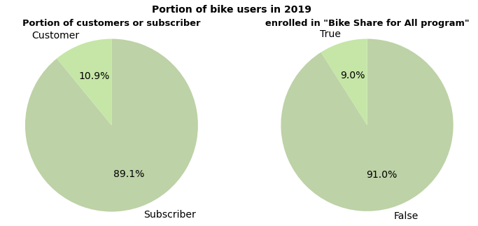

```python
#create figure and axes object and setting number of columns of subplit grid
fig,(ax1,ax2)=plt.subplots(figsize=(12,5),ncols=2)
colors=["#BDD2A6","#C5E6A6"]
fig.suptitle('Portion of bike users in 2019', fontsize=14, fontweight='bold')
user_type=df.user_type.value_counts()
bike_sh=df.bike_share_for_all_trip.value_counts()
# first axes plotting Portion of user_type
_=ax1.pie(user_type,labels=user_type.index,startangle=90,counterclock=False,
       wedgeprops={'width':1},autopct='%1.1f%%',textprops={'fontsize': 14},
         colors=colors)
_=ax1.set_title("Portion of customers or subscriber",size=13,fontweight='bold')
# Equal aspect ratio ensures that pie is drawn as a circle
_=ax1.axis('equal')

# Second  axes plotting Portion of bike_sh
_=ax2.pie(bike_sh,labels=bike_sh.index,startangle=90,counterclock=False,
         wedgeprops={'width':1},autopct='%1.1f%%',textprops={'fontsize': 14},
          colors=colors)
_=ax2.set_title("enrolled in \"Bike Share for All program\""
               ,size=13,fontweight='bold')
# Equal aspect ratio ensures that pie is drawn as a circle
_=ax2.axis('equal')
```

## Observation:

### Right pie chart:

This pie chart shows the portion of users enrolled in "Bike Share for All Program" and the majority in the dataset are not. Bike Share for All is available to Bay Area residents ages 18 and older who qualify for Calfresh, SFMTA Lifeline Pass, or PG&E CARE utility discount.

### Left pie chart:

This pie chart shows the portion of bike users wether They're a Customers or subscribers, the pie chart indicates that the majority are subscribed. The reason for that Probably because the fact that single rides start at \$2 for the first 30 minutes, then \\$2 per additional 15 minutes for the casual users whereas an annual membership has unlimited 45-minute Classic bike rides and discounted ebikes: Free unlocks and $0.15 per minute (waived if no Classic bikes available)

**Resource:** https://www.lyft.com/bikes/bay-wheels/bike-share-for-all

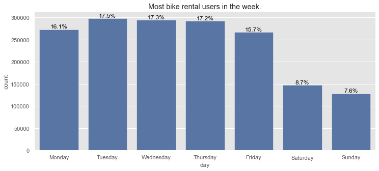

```python
#create the plot
sb.set(rc={'figure.figsize':(12,5)})
dayofweek=['Monday', 'Tuesday','Wednesday','Thursday'\
 ,'Friday','Saturday', 'Sunday']
color=sb.color_palette()[0]
with plt.style.context('ggplot'):
    sb.countplot(data=df,x="day", color= color,order=dayofweek)
    plt.title("Most bike rental users in the week.")

    #add annotations
    n_points=df.shape[0]
    day_counts=df['day'].value_counts()
    locs,labels=plt.xticks()#get the current tick locations and labels

    #loop thru each pair of locations nd labels
    for loc,label in zip(locs,labels):

        #get the text property for the label to get the correct count
        count=day_counts[label.get_text()]
        pct_string='{:0.1f}%'.format(100*count/n_points)

        # print the annotation at the top of the bar
        plt.text(loc,count-8,pct_string,ha='center',color='black',va='bottom',fontsize=12)
```

## Observation:

```python
np.percentile(df.duration_min,100)
```

```
1438.0166666666667
```

```python
(df.duration_min).describe()
```

```
count   1699701.000000
mean         12.433383
std          30.752407
min           1.016667
25%           5.750000
50%           9.000000
75%          13.800000
max        1438.016667
Name: duration_min, dtype: float64
```

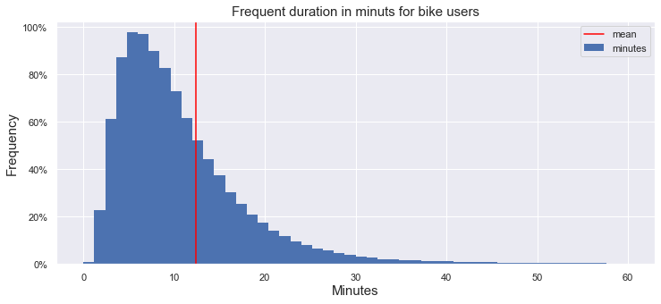

```python
from matplotlib.ticker import PercentFormatter
weights=np.ones(df.shape[0])/df.shape[0]

_=plt.hist(x=df.duration_min,lw=0,bins=50,range=(0,60),weights=weights)
_=plt.axvline(x=(df.duration_min).mean(),color='red')
plt.gca().yaxis.set_major_formatter(PercentFormatter(.1))
_=plt.title("Frequent duration in minuts for bike users",size=15)
_=plt.ylabel("Frequency",size=15)
_=plt.xlabel("Minutes",size=15)
_=plt.legend(["mean","minutes"])
```

## Observation:

Here is a right skewed distribution of duration in minutes for our data (aka positively skewd distribution). The majority falls between 3 and 7 minuts bike rids.

The reason that most bike users are below 60 is probably because bay-wheels bike share charges for rides longer than 60 minutes for $3 in each additional 15 minutes.

```python
df.columns
```

```
Index(['duration_min', 'day', 'start_time', 'end_time', 'distance_km',
       'start_station_id', 'start_station_name', 'start_station_latitude',
       'start_station_longitude', 'end_station_id', 'end_station_name',
       'end_station_latitude', 'end_station_longitude', 'user_type',
       'bike_share_for_all_trip'],
      dtype='object')
```

```python
print("mean>median:",np.mean(df.duration_min),">",np.percentile(df.duration_min,50))
```

```
mean>median: 12.433382567483898 > 9.0
```

```python
df[["distance_km"]].describe()
```

|  | distance_km |
| --- | --- |
| count | 1699701.000000 |
| mean | 1.636539 |
| std | 1.002188 |
| min | 0.013287 |
| 25% | 0.910955 |
| 50% | 1.401815 |
| 75% | 2.104143 |
| max | 65.309254 |

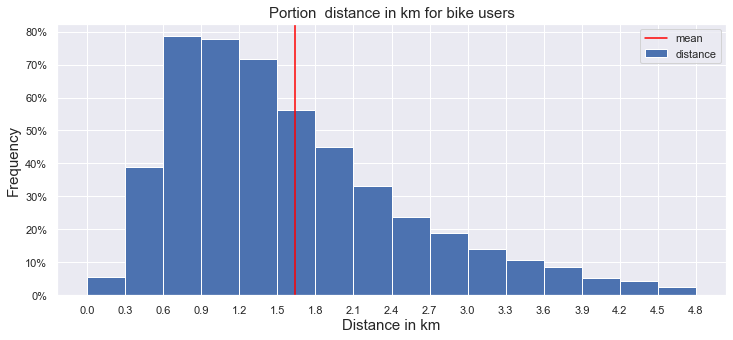

```python
weights=np.ones(df.shape[0])/df.shape[0]

_=plt.hist(df.distance_km,bins=np.arange(0,5,.3),range=None,weights=weights,lw=1)
plt.gca().yaxis.set_major_formatter(PercentFormatter(.2))
_=plt.axvline(x=df.distance_km.mean(),color='red')
_=plt.title("Portion  distance in km for bike users",size=15)
_=plt.ylabel("Frequency",size=15)
_=plt.xlabel("Distance in km",size=15)
_=plt.xticks(np.arange(0,5,.3))
_=plt.legend(["mean","distance"])
```

## Observation:

For distance we have a right skewed distribution, the mean is typically greater than the median. Also notice that the tail of the distribution on the right hand (positive) side is longer than on the left hand side.

```python
print("mean>median:",np.mean(df.distance_km),">",np.percentile(df.distance_km,50))
```

```
mean>median: 1.6365389166388251 > 1.4018148489428044
```

### Of the features you investigated, were there any unusual distributions? Did you perform any operations on the data to tidy, adjust, or change the form of the data? If so, why did you do this?

```python
# df.to_csv("cleaned_combined.csv",index=False)
```

# Bivariate visualization.

## Exploring distribution of the dataset and variables Understanding the relation between the various variables.

we will explore selected variable and try to see the correlation between each one using visualization.

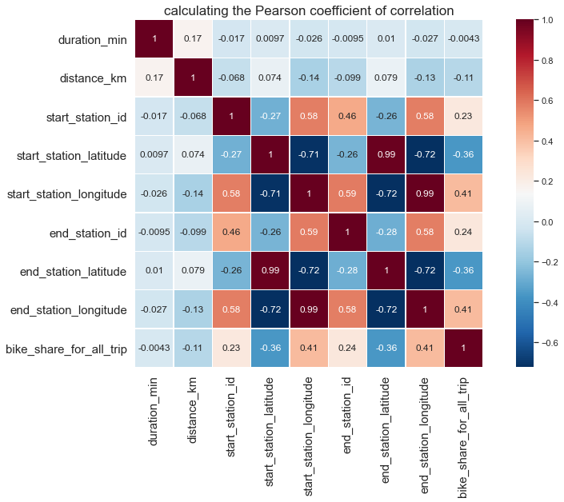

```python
pearsoncorr=df.copy()
pearsoncorr=pearsoncorr.corr(method='pearson')#new data frame that holds the pearson correlation
plt.figure(figsize=(15,8))#create a figure object
_=sb.heatmap(pearsoncorr,cmap='RdBu_r',
           annot=True,annot_kws={'size':12},
           linewidth=0.5,square=True)#visualization

plt.xticks(size=15);plt.yticks(size=15)#setting x & y tick size
_=plt.title("calculating the Pearson coefficient of correlation",size=17)# creating title
```

# Observation:

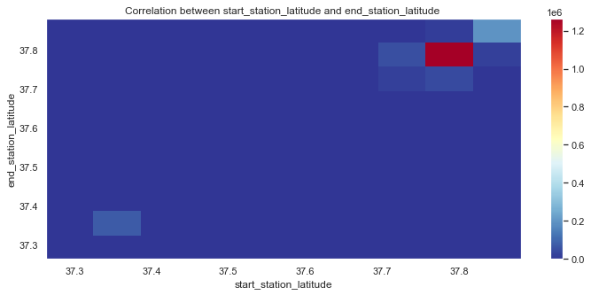

```python
from matplotlib.colors import LogNorm
fig, ax = plt.subplots()#create figure and axis for the plot
# create 2d hist for start station latitude in the x axis and end station latitude in the y axis
h=ax.hist2d(x=df.start_station_latitude,y=df.end_station_latitude,cmap=plt.cm.RdYlBu_r)
plt.colorbar(mappable=h[3],ax=ax)
plt.title("Correlation between start_station_latitude and end_station_latitude ")
plt.ylabel("end_station_latitude")
plt.xlabel("start_station_latitude")
# h[3]-> get the image from the return value so it knows what colormap and limits for colorbar
```

# Observation:

In the 2d histogram we visualize the variables that are highly correlated which are start_station latitude and end_station latitude.

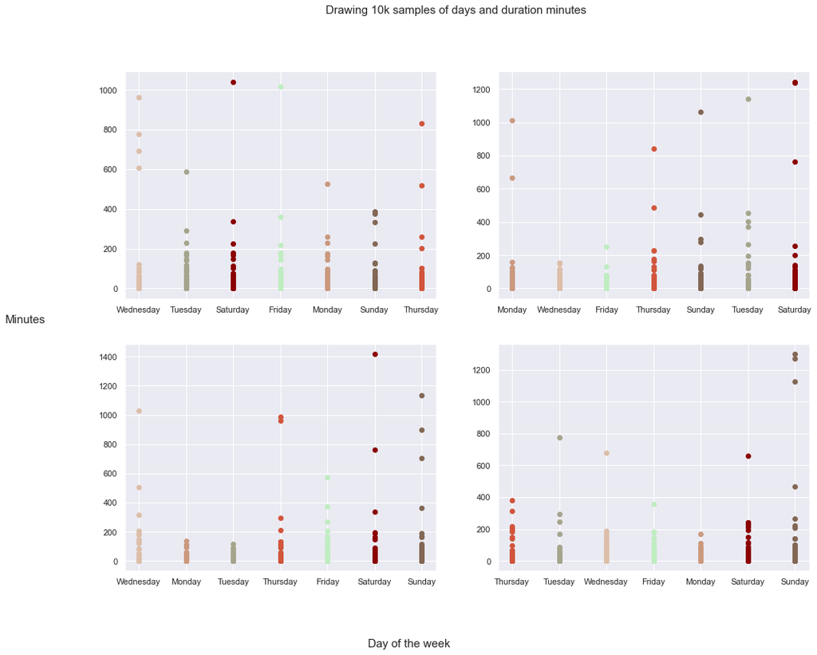

```python
fig,ax=plt.subplots(ncols=2,nrows=2,figsize=(16,12))#create 4 figures
#rows,columns and inter these are to iterate over each figure
rows=[0,1,0,1]
columns=[0,0,1,1]
inter=list(zip(rows,columns))
'''the below nested for loop will iterate over each axis of the figure
and draw a random 10k sample of duration and day '''
for j in range(len(inter)):# This will loop 4 times
    sam=df.sample(10_000)#set 10k sample df each loop
    for i in sam.index:#calculate days and duration for each figure
        if (sam['day'][i]=='Monday'):
            ax[inter[j]].scatter(sam['day'][i],sam['duration_min'][i],color='#CB997E',label='Monday')
        elif (sam['day'][i]=='Sunday'):
            ax[inter[j]].scatter(sam['day'][i],sam['duration_min'][i],color='#826754',label='Sunday')
        elif (sam['day'][i]=='Saturday'):
            ax[inter[j]].scatter(sam['day'][i],sam['duration_min'][i],color='#8B0000',label='Saturday')
        elif (sam['day'][i]=='Friday'):
            ax[inter[j]].scatter(sam['day'][i],sam['duration_min'][i],color='#BFEDC1',label='Friday')
        elif (sam['day'][i]=='Thursday'):
            ax[inter[j]].scatter(sam['day'][i],sam['duration_min'][i],color='#D1553B',label='Thursday')
        elif (sam['day'][i]=='Wednesday'):
            ax[inter[j]].scatter(sam['day'][i],sam['duration_min'][i],color='#DDBEA9',label='Wednesday')
        elif (sam['day'][i]=='Tuesday'):
            ax[inter[j]].scatter(sam['day'][i],sam['duration_min'][i],color='#A5A58D',label='Tuesday')

# lines_labels = [ax.get_legend_handles_labels() for ax in fig.axes]
# lines, labels = [sum(lol, []) for lol in zip(*lines_labels)]
# fig.legend(lines, labels)

fig.suptitle("Drawing 10k samples of days and duration minutes",fontsize=15)#title
fig.text(-.01,.5,'Minutes',fontsize=15)#y label position
fig.text(.4,.01,'Day of the week',fontsize=15)# xlabel position
plt.show()#this will remove unwanted text
```

# Each day in every graph has the same color to compare them easily.

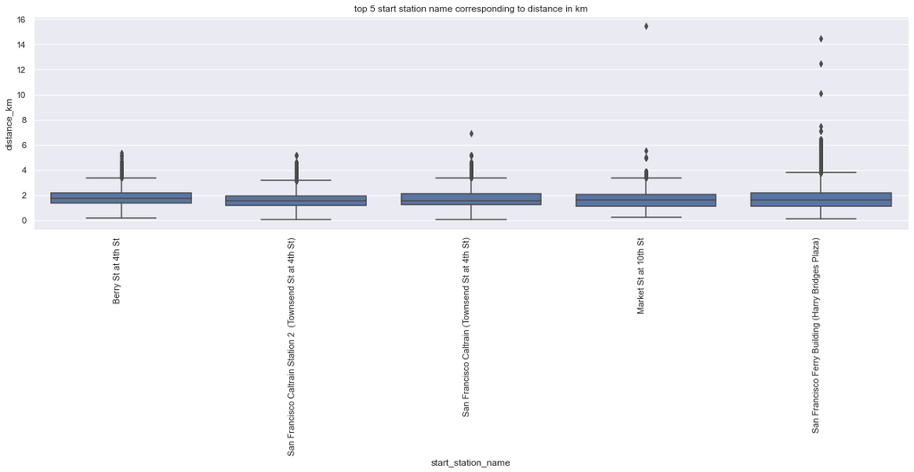

```python
plt.figure(figsize=(20,5))
#plotting top 5 start station
sb.boxplot(
    data=df.loc[df['start_station_name'].isin(df.start_station_name.value_counts().index[:5])],
    x='start_station_name',
    y='distance_km',
    color=color)
# plt.yscale('log')
plt.title('top 5 start station name corresponding to distance in km')
plt.xticks(rotation=90, ha='right')
plt.show()
```

# Observation:

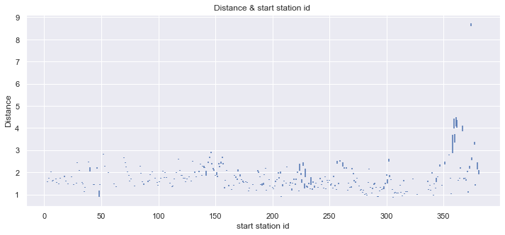

```python
bin_size=0.25
xbin_edges=np.arange(0.6,df.start_station_id.max()+bin_size,bin_size)
xbin_centers = (xbin_edges + bin_size/2)[:-1]

duration_binned=pd.cut(df.start_station_id,xbin_edges,right=False,include_lowest=True)
distance_mean=df['distance_km'].groupby(duration_binned).mean()
distance_sems=df['distance_km'].groupby(duration_binned).sem()
plt.errorbar(x=xbin_centers,y=distance_mean,yerr=distance_sems)
plt.title("Distance & start station id ")
plt.xlabel("start station id")
plt.ylabel("Distance")
plt.show()
```

# Observation:

### Did you observe any interesting relationships between the other features (not the main feature(s) of interest)?

# Multivariate visualization.

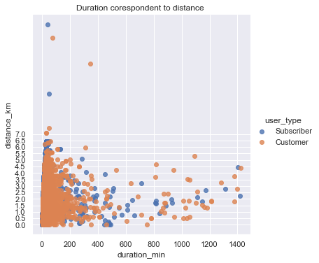

```python
# plt.figure(figsize=(4,20))
_=sb.lmplot(x='duration_min',y='distance_km',hue='user_type'
         ,data=df.loc[df['start_station_name'].isin(df.start_station_name.value_counts().index[:3])],fit_reg=False)
_=plt.yticks(np.arange(0,7.5,0.5))
_=plt.title("Duration corespondent to distance ")
```

# Observation:

```python
df.start_station_name.value_counts().index[:3]
```

```
Index(['San Francisco Caltrain Station 2  (Townsend St at 4th St)',
       'Market St at 10th St',
       'San Francisco Ferry Building (Harry Bridges Plaza)'],
      dtype='object')
```

# Observation:

```python
from scipy import stats
def quantile_plot(x, **kwargs):
    qntls, xr = stats.probplot(x, fit=False)
    plt.scatter(xr, qntls, **kwargs)

g = sb.FacetGrid(df, col="user_type", height=4)
g.map(quantile_plot, "bike_share_for_all_trip");
plt.xticks([0,1],["True","False"])
plt.ylabel('Frequency')
```

[output not shown]

# Observation:

```python
df.query("user_type=='Customer' and bike_share_for_all_trip==@True")
```

[output not shown]

```python
df['month'] = df['start_time'].dt.month
```

```python
df['start_time'].dt.month
```

```python
fig = plt.figure(figsize = (12,6))
sb.pointplot(data = df, x = 'month' , y = 'duration_min' , hue = 'user_type', palette = 'Reds')
plt.title('Trip duartion across user type in different months')

plt.ylabel('Mean  Dduration ')
# plt.xticks([1,2,3,4,5,6,7,8,9])
plt.xlabel('Month')
plt.show()
```

[output not shown]

```python
df.to_csv("cleaned_combined.csv",index=False)
```

# Observation:

source: https://seaborn.pydata.org/tutorial/axis_grids.html